# Example Solution

Daniel W. Kennedy

September 24, 2019

## Example

```r
devtools::find_rtools(debug = TRUE)
```

```
## Scanning R CMD config CC...
## cc_path: C:/RBuildTools/3.5/mingw_64/bin/gcc
## install_path: C:/RBuildTools/3.5
## VERSION.txt
## Rtools version 3.5.0.4
## Found compatible gcc from R CMD config CC
```

```
## [1] TRUE
```

```r
library(rstan)
```

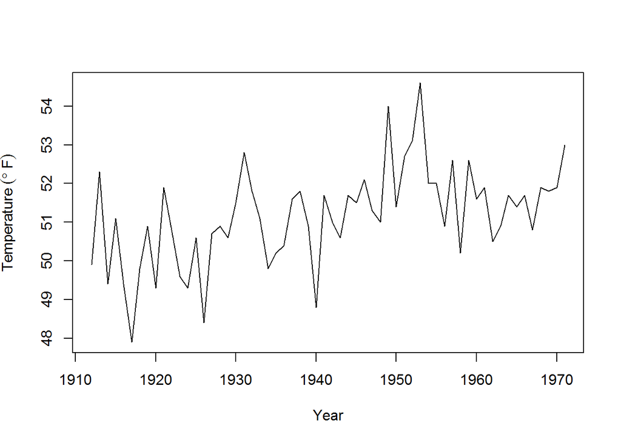

```r
data("nhtemp")
plot(nhtemp,ylab = expression(Temperature ~(degree~"F")),xlab = "Year")
```

The `nhtemp` data-set in R is a time series of temperatures (measured in $^\circ$F) collected in New Haven, Connecticut over 60 years from 1912-1971. The proposed model for the process is that the temperature depends on the previous year’s temperature as well global temperatures, which are assumed to rise linearly each year:
$$y_i = \alpha + \beta y_{i-1} +\gamma i + \epsilon_i,$$
where
$$\epsilon_i \sim \text{Normal}{\left(0,\sigma^2\right)}.$$

Explanation for each parameter is:

- $\alpha$ is an “intercept” temperature (it does not correspond exactly correspond to the expected temperature at $i=0$ as the stationary mean is $\alpha/\left(1-\beta\right)$$^\circ$F)
- $\beta$ is the first order autocorrelation parameter. If $\beta$ is 0, then there is no autocorrelation, whereas if $\beta$ is less than or greater than 0, then the current value $y_i$ will be dependent on the previous value $y_{i-1}$.
- $\gamma$ is the linear trend, where each year the average temperature increases by $\gamma$$^\circ$F.

Use this code as a template for your Stan model:

```stan
data {
  int<lower=0> N;
  int<lower=2> N_new;
  vector[N] y;
}

parameters {

}

model {
  for (n in 2:N){
    y[n] ~ normal(FILL, FILL);
  }
}

generated quantities{
  real y_new[N_new];
  y_new[1] = normal_rng(FILL, FILL);
  for (n in 2:N_new){
    y_new[n] = normal_rng(FILL, FILL);
  }
}
```

## Solution:

The following Stan model should allow us to estimate the model parameters and forecast temperature for proceeding years:

```stan
data {
  int<lower=0> N;
  int<lower=2> N_new;
  vector[N] y;
}

parameters {
  real gamma;
  real alpha;
  real beta;
  real<lower=0> sigma;
}
model {
  for (n in 2:N)
    y[n] ~ normal(alpha + beta * y[n-1] + gamma * n, sigma);
}

generated quantities{
  real y_new[N_new];
  y_new[1] = normal_rng(alpha + beta * y[N] + gamma * (N + 1), sigma);
  for (n in 2:N_new){
    y_new[n] = normal_rng(alpha + beta * y_new[n-1] + gamma * (n + N), sigma);
  }
}
```

We now compile the model and sample for 5000 iterations on 4 parallel chains:

```r
ts_ar1.stanmodel <- stan_model(file = "models/ts_ar1.stan")
ts_ar1.stanfit <- sampling(ts_ar1.stanmodel,
                           data = list(
                             N = length(nhtemp),
                             N_new = 20,
                             y = as.vector(nhtemp)),
                           iter = 5000,
                           chains = 4,
                           warmup = 1000)
```

We can now use the fabulous `ggmcmc` package to plot our MCMC chains and make sure that they have converged:

```r
library(ggmcmc)
```

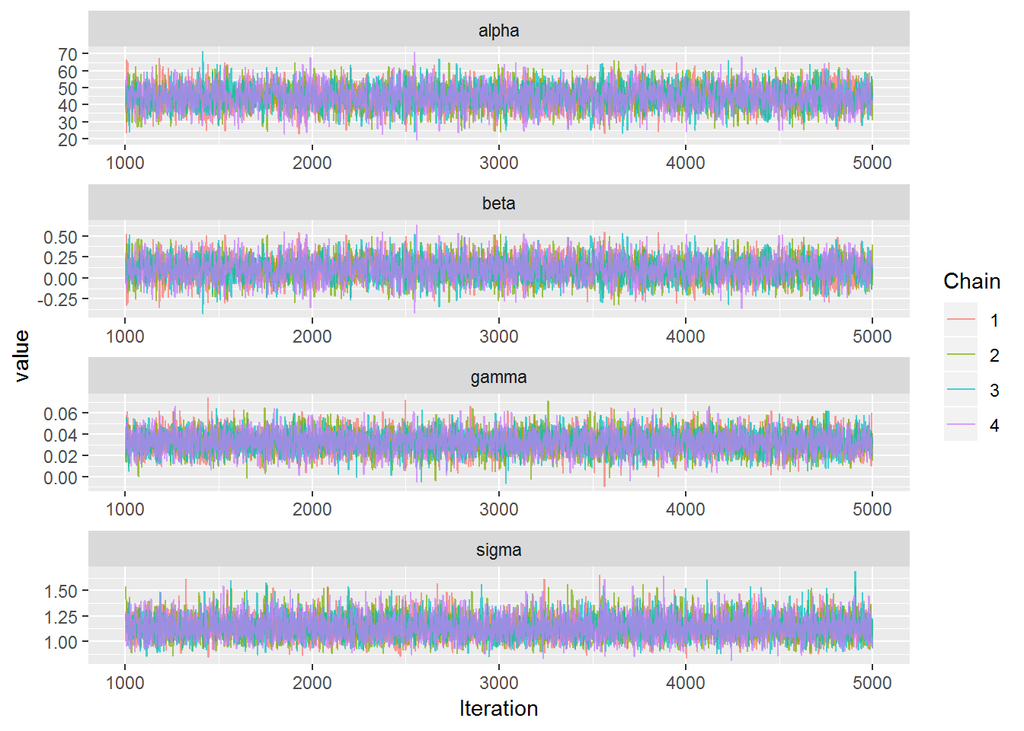

```r
ggs_traceplot(ggs(ts_ar1.stanfit),family = c("gamma|alpha|beta|sigma"))
```

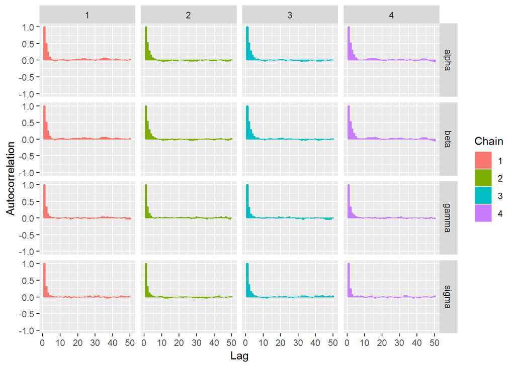

```r
ggs_autocorrelation(ggs(ts_ar1.stanfit),family = c("gamma|alpha|beta|sigma"))
```

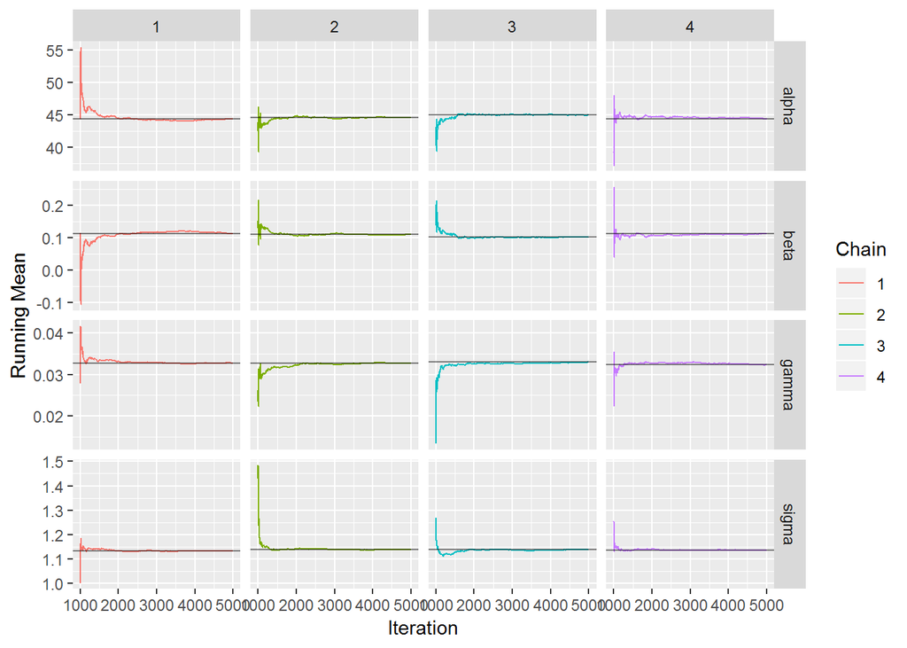

```r
ggs_running(ggs(ts_ar1.stanfit),family = c("gamma|alpha|beta|sigma"))
```

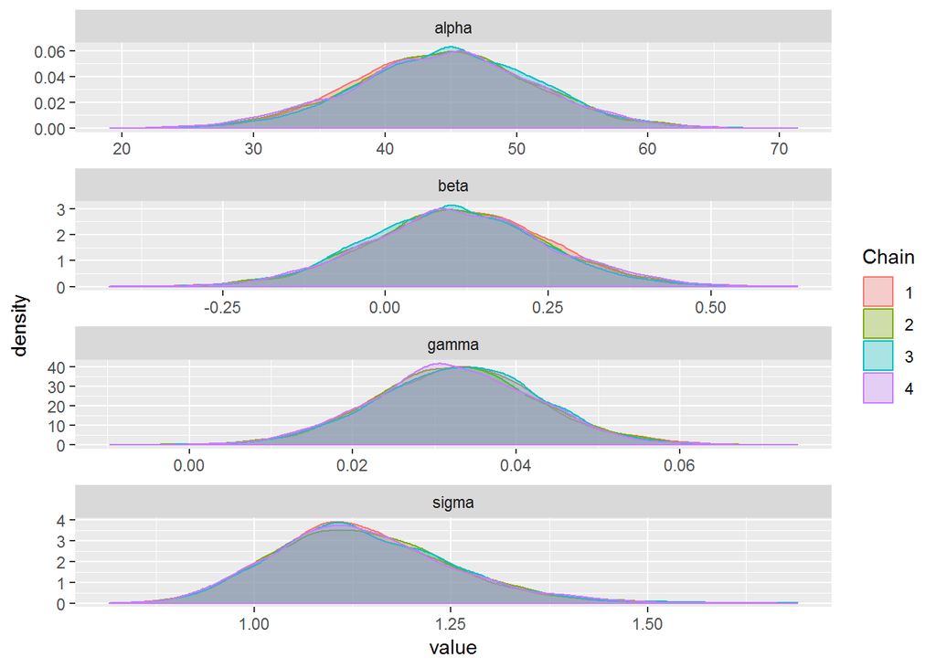

```r
ggs_density(ggs(ts_ar1.stanfit),family = c("gamma|alpha|beta|sigma"))
```

We can get numerical summaries for your parameters as well:

```r
print(ts_ar1.stanfit,pars = c("gamma","alpha","beta","sigma"))
```

```
## Inference for Stan model: ts_ar1.
## 4 chains, each with iter=5000; warmup=1000; thin=1;
## post-warmup draws per chain=4000, total post-warmup draws=16000.
##
##        mean se_mean   sd  2.5%   25%   50%   75% 97.5% n_eff Rhat
## gamma  0.03    0.00 0.01  0.01  0.03  0.03  0.04  0.05  7270    1
## alpha 44.57    0.09 6.83 30.96 40.10 44.67 49.11 57.96  5188    1
## beta   0.11    0.00 0.14 -0.16  0.02  0.11  0.20  0.38  5144    1
## sigma  1.14    0.00 0.11  0.94  1.06  1.13  1.21  1.38  7611    1
##
## Samples were drawn using NUTS(diag_e) at Tue Sep 24 12:54:22 2019.
## For each parameter, n_eff is a crude measure of effective sample size,
## and Rhat is the potential scale reduction factor on split chains (at
## convergence, Rhat=1).
```

We can extract and plot our forecasted temperatures using the `As.mcmc.list()` function. There may be a simpler way of converting the MCMC samples to a data-frame, however using the `do.call()` and `lapply()` functions are used here:

```r
predictions <- As.mcmc.list(ts_ar1.stanfit,pars = "y_new")
predictions <-
  do.call(
    rbind.data.frame,
    lapply(1:4, function(x){return(cbind(predictions[[x]],chain = x,iter = 1:nrow(predictions[[x]])))}))

library(reshape2)
```

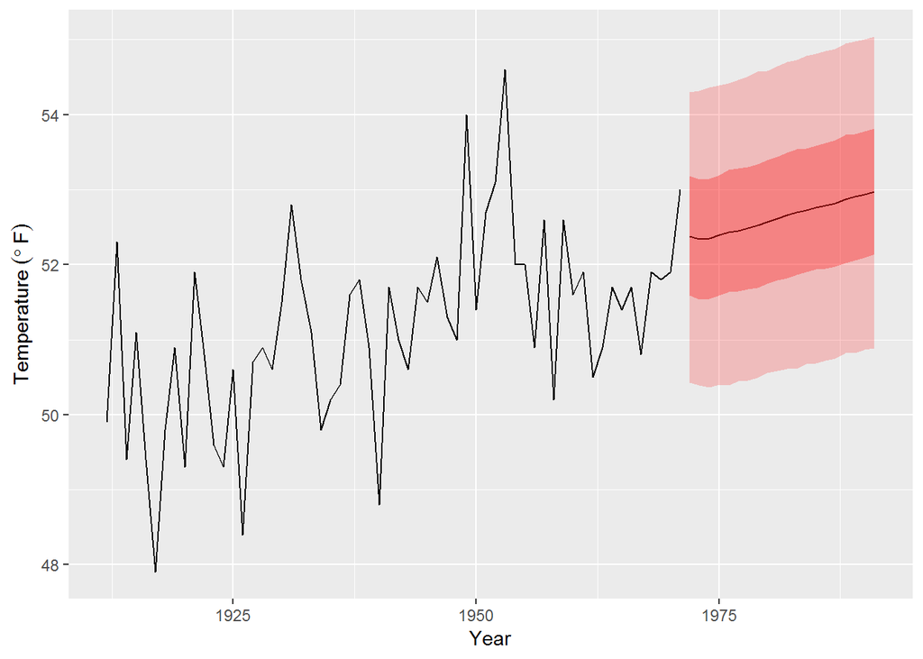

```r
predictions <- predictions %>% melt(id = c("chain","iter"))
# Convert the year to a numeric variable:
levels(predictions$variable) <- 1971 + 1:length(levels(predictions$variable))
predictions$variable <- as.numeric(as.character(predictions$variable))

# Calculate the mean, upper and lower quartiles, and bounds for a 90% Prediction Interval.
prediction_summary <-
predictions %>% group_by(variable) %>%
  summarise(mean = mean(value),
            upper_q = quantile(value,0.75),
            lower_q = quantile(value,0.25),
            upper_ci = quantile(value,0.95),
            lower_ci = quantile(value,0.05))

# Plot the real data:
plot <- ggplot() + geom_line(data = data.frame(y = as.vector(nhtemp), x = 1912:1971),aes(x=x,y=y))

# Plot the mean prediction
plot <- plot + geom_line(data = prediction_summary, mapping = aes(x = variable, y = mean))

# Plot the upper and lower quartiles as a ribbon:
plot <- plot + geom_ribbon(
  data = prediction_summary,
  mapping = aes(x = variable, ymin = lower_q, ymax = upper_q),alpha = 0.3, fill = "red")

# Plot the 90% Prediction interval as a lighter ribbon.
plot <- plot + geom_ribbon(
  data = prediction_summary,
  mapping = aes(x = variable, ymin = lower_ci, ymax = upper_ci),alpha = 0.2, fill = "red")
plot <- plot + labs(y = expression(Temperature ~(degree~"F")),x = "Year")
plot
```